# Classification of business activities by machine learning: the case of France

**Somali statistics delegation’s visit**

24 September 2026

## Outline

01

About me

02

Table of contents

03

1️⃣ Recap and context

04

2️⃣ State of play: How do we assign activity codes today ?

05

3️⃣ Why did we end up using Machine Learning ?

06

4️⃣ fastText: a simple and efficient classifier

07

5️⃣ Beyond fastText: introducing TorchTextClassifiers

08

6️⃣ NACE Rev 2.1: update our classifier using LLMs

09

Questions ?

# 1 About me

- **Who am I ?**
  - **Nathan Randriamanana**
  - *Data scientist* at Insee
  - INSEE statistician [**civil servant**](https://www.insee.fr/en/information/2404684#attaches)
  - working now at the **Business Statistics Directorate**
  - [**SIRENE**](https://www.insee.fr/en/metadonnees/definition/c1135) business register

## 1.1 [About my job](https://www.linkedin.com/in/nathan-randriamanana-69a1721b3/)

- **I wear two hats**:
  - **🎩 Application Administrator**: Acting as the functional lead for the SIRENE register. I bridge the gap between business needs and IT by writing functional specifications for system maintenance and evolution.
  - **🧢 Data Scientist**: Managing the end-to-end ML workflow for APE classification from model training and delivery to its integration into the production application.

[figure not shown]

### Linkedin

# 2 Table of contents

1️⃣ **Context**

2️⃣ **State of play: How do we assign activity codes today ?**

3️⃣ **Why did we end up using Machine Learning ?**

4️⃣ **fastText: a simple and efficient classifier**

5️⃣ **Beyond fastText: introducing TorchTextClassifiers**

6️⃣ **NACE Rev 2.1: update our classifier using LLMs**

# 3 1️⃣ Recap and context

## 3.1 Quick reminder: What is SIRENE ?

System for the Identification of the Register of Enterprises and Establishments

- **Sirene** is the French national company registry
- When a company registers:
  - sole authority for issuing **SIREN** and **SIRET** numbers
  - a **main activity code** is attributed (**APE** code)
- Milestones and challenges faced:
  - Refactoring of the Sirene **information system** **Sirene 4**
  - NACE revision ➡️ dual coding in NACE rev 2 and 2.1
- End of March 2024:
  - Officially switch from **Sirene 3** to **Sirene 4**
- Processing **5 million registrations** across 2025–2026 🚀
- **2027**: Transition to NACE rev 2.1
- **Consequences**: Ideal moment to innovate (but under the constraint!)

## 3.2 A one-stop shop

Another key actor: *National Industrial Property Institute*

- **INPI** is the operator of the **one-stop shop** (Single Window)
- This replaces the old paper-based **CFE** (Business formality centers)
- It is the **primary data source** for the Sirene registry
- Implementation of the **PACTE Law (2019)** to simplify the French economy

**PACTE law**

Since January 1, 2023, all business formalities must be filed online via a single portal.

## 3.3 The flow” of formalities

[figure not shown]

## 3.4 The administrative landscape

- Siren number: company directory identification system
- Principal activity code (APE)
- Classification on a daily basis
- Different administrations
- Different information systems
- Requirements: quick, responsive and flexible to updated instructions

# 4 2️⃣ State of play: How do we assign activity codes today ?

## 4.1 Assign an activy code: different processes

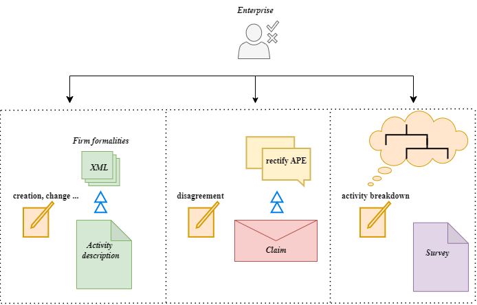

## 4.2 Assign an activy code: two outcomes

- Automatic coding
- Human review

[figure not shown]

## 4.3 Near-ubiquity of ML

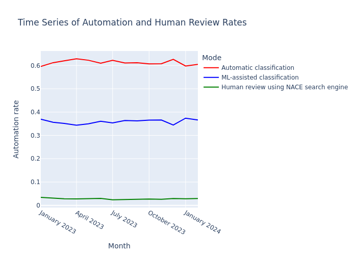

## 4.4 Automatic activity classification

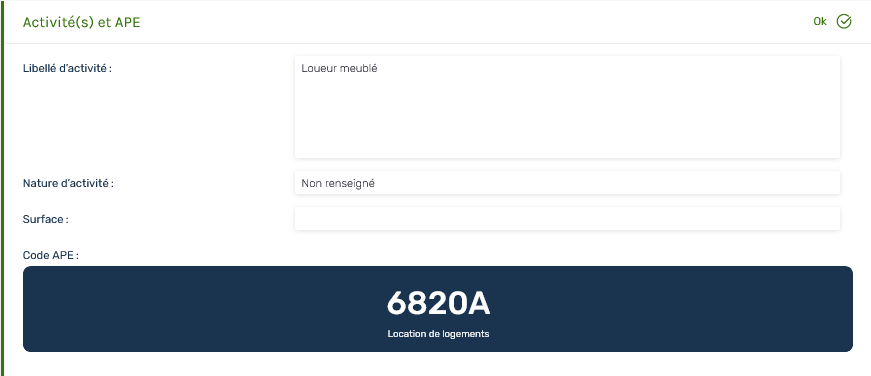

## 4.5 Human review

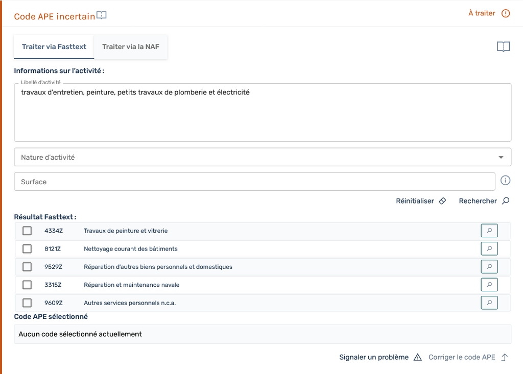

## 4.6 Model

- **Text classification** model which uses additional categorical variables
- Historically, a system expert named **SICORE** as automatic label coding system
- First ML usecase with **fastText** library
- Originally trained on legacy data annotated partly by the **coding engine** and partly **manually**

# 5 3️⃣ Why did we end up using Machine Learning ?

## 5.2 The shock

**Display an exemple of activity description from business formality centers**

```
  BAKERY
```

**Display an exemple of activity description from the one-stop-shop**

```
 I am looking to developpe in the cleaning and maintainance of busines offices: changeing bins, vacuuming, and mopping
```

# 6 4️⃣ fastText: a simple and efficient classifier

## 6.1 A package from FAIR lab

[figure not shown]

- Up until November 2022, we used an automatic label coding system, called Sicore
  - Based on a training file of encoding examples
  - Drawbacks : if the label did not match an encryption example, no code suggestion was returned. It was then coded manually by a human being
- Since November 2022, we have implemented a new model based on machine
- Very accurate even with literal descriptions that have never been coded before
- A 100 % result even with a low accuracy rate (always outputs an answer …)
- However we have decided to maintain a manual check if the accuracy is not good

## 6.2 Feature extraction

- **Word embedding**: a method of **vectorisation**.
- **Pre-trained** embeddings available in open-source.
- We learn **our own** **word** embeddings.
- Additionally, embeddings for:
  - **word n-grams** and **character n-grams**.

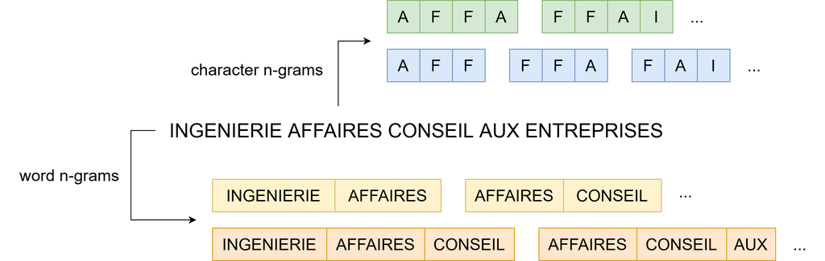

## 6.3 Linear classifer

- **2 classification methods**:
  - **Softmax**: a **single** multiclass classifier.
  - **One-vs-all**: **multiple** binary classifiers.
- **Optimisation**: **stochastic gradient descent** algorithm.
- **Loss function**: **cross-entropy**.

## 6.4 fastText model

- **fastText**: very **simple** and **fast** (`C++`) “bag of n-grams” model.

## 6.5 Handling categorical variables

- **Concatenation** of the text description with the names and values of the auxiliary variables:

| Text | NAT | TYP | EVT | SUR |
| --- | --- | --- | --- | --- |
| Cours de musique | NaN | X | 01P | NaN |

🢃

“Cours de musique NAT_NaN TYP_X EVT_01P SUR_NaN”

- **Imperfect method**: 3-grams “AT_” or “T_0” used.

## 6.6 Preprocessing

- **Preprocessing** essential for natural language processing.
- **Constraints**: **simple**, **light** and easily **reproducible** in Java .

| Transformation | Text description |
| --- | --- |
| Input | 3 D: La Deratisation - La Desinsectisation - La Desinfection |
| Lower-case conversion | 3 d: la deratisation - la desinsectisation - la desinfection |
| Punctuations removal | 3 d la deratisation la desinsectisation la desinfection |

## 6.7 Preprocessing

| Transformation | Text description |
| --- | --- |
| Input | 3 D: La Deratisation - La Desinsectisation - La Desinfection |
| … | … |
| Numbers removal | d la deratisation la desinsectisation la desinfection |
| One-letter word removal | la deratisation la desinsectisation la desinfection |
| Stopwords removal | deratisation desinsectisation desinfection |

## 6.8 Preprocessing

| Transformation | Text description |
| --- | --- |
| Input | 3 D: La Deratisation - La Desinsectisation - La Desinfection |
| … | … |
| NaN removal | deratisation desinsectisation desinfection |
| Stemming | deratis desinsectis desinfect |

## 6.9 Modeling

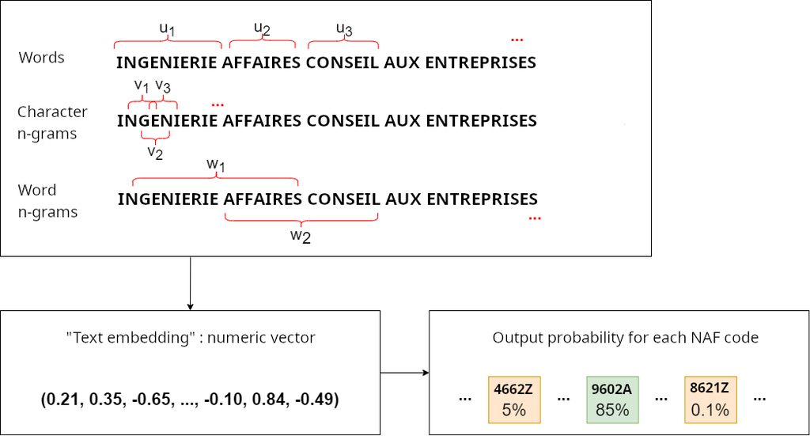

# 7 5️⃣ Beyond fastText: introducing TorchTextClassifiers

## 7.2 The Stakes

- Lack of library maintenance: eventual risks regarding stability and compatibility.
- Most importantly: it **stalls modernization**.
- Meanwhile, a highly dynamic **Deep Learning/NLP** ecosystem: **PyTorch**, **Hugging Face**, etc.

## 7.3 2025: Transitioning to PyTorch!

- PyTorch model closely mirrors the fastText architecture: a smooth transition.
- Discussed [here](https://inseefrlab.github.io/codif-ape-prez/slides/grp-veille-codif-auto-10/#/title-slide):
  - PyTorch allows for *customized* architectures tailored to our needs (handling categorical variables).
  - Improved **training monitoring**.
  - Opportunities for modernization: explainability, calibration, **higher-performance models**…
- A dedicated package to decouple model definition from its implementation.

## 7.4 From *torchFastText* to *torchTextClassifiers*

- Evolution from a single package into a **toolkit** (a unified framework) for text classification with categorical variables.
  - Inspired by other PyTorch toolkits: [Pythae](https://github.com/clementchadebec/benchmark_VAE) for VAEs, TorchSeg for segmentation…
- Conceptualization of the various components within a text classification model.
- Seamless integration with the **Hugging Face** ecosystem.

## 7.5 Library scope and positioning

[figure not shown]

From a production standpoint

- If you want to know more, get [here](https://github.com/InseeFrLab/torchTextClassifiers/tree/main) and star this repo 🌟

## 7.6 Architecture

[figure not shown]

## 7.7 Features

- Explainability 🔍 🤖 📊
- Multi-label support 🏷️
- Modular design 🧩⚙️

## 7.8 Get started

1. check out the [example notebook](https://github.com/InseeFrLab/torchTextClassifiers/blob/main/notebooks/example.ipynb) 📚 🚀
2. import your own data in **Load and preprocess data**
3. Choose your section based on your goal
   - **torchTextClassifiers: a wrapper to handle them all** ☺️ ➡️ Fast implementation: just grab-and-go 🛍️
   - **Let’s dive into the different components** 🤓 (experts) ➡️ More control: modular customization 🔧 👌 😎

**Some tips for data import**

Just update the import section and match your column names.  
Works out-of-the-box with Parquet or [CSV](https://pandas.pydata.org/docs/reference/api/pandas.read_csv.html) for instance (Can ask our [AI chat](https://llm.lab.sspcloud.fr/))

# 8 6️⃣ NACE Rev 2.1: update our classifier using LLMs

## 8.1 Statistical classifications, briefly

The Problem

**What NACE is**

- The EU classification of **economic activities**
- Every business unit in production registers gets a NACE code
- Hierarchical: section → division → group → class → sub-class
- Revised every ~15 years — the current move: NACE 2.0 → NACE 2.1

**The French specificity: NAF**

- Nomenclature d’Activités Française: The national adaptation of NACE, managed by INSEE
- Same structure as NACE + an extra 5th character (a letter) for national specifics
- Assigned to every French company as the well-known APE code (Activité Principale Exercée)

**Note**

Our work was actually conducted using the French **NAF**. However, I will use **NACE** in this presentation to make it more universally understandable and to demonstrate that our approach perfectly adapts to this broader European classification level.

## 8.2 When a classification is revised

A recurring challenge for every statistical institute (NACE, COICOP, ISCO, …).

**Standard ML maintenance**

- Inputs may drift over time
- We monitor and **retrain on fresh labels**
- The target variable stays the **same**

**Classification revision**

- The **target variable itself changes**
- New labelled data are **scarce or missing**
- Legacy labels are in the **wrong space**
- Standard retraining is **not possible**
- At Insee, a **TorchTextClassifiers** classifier (fastText-inspired) in production since 2025-2026 to assign NACE 2.0 codes
- Trained on a 2.7-million-label training set.

**Central question**: how can we leverage years of accumulated production knowledge in the old classification to bootstrap a model in the new one?

## 8.3 Our strategy: shifting the old trainset

The Problem

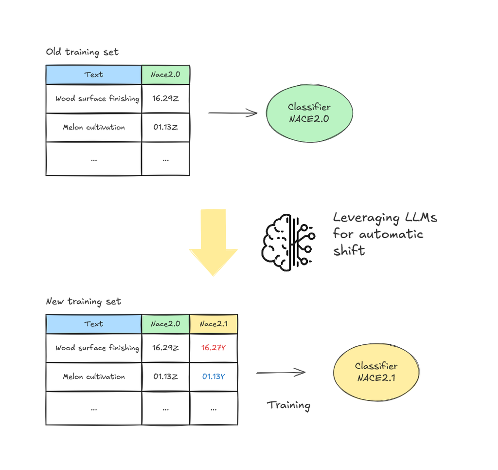

## 8.4 NACE 2.0 → 2.1 and the one-to-many codes

The Problem

**Scope of the change**

**Complexity lies in non-bijective cases!**

- Univocal: one-to-one mapping
- One-to-many: 1-to-many relation (~2 to 5)

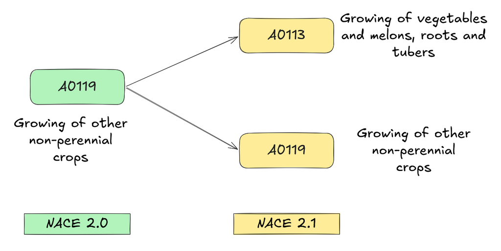

## 8.5 The scale of the problem

The Problem

|  | One-to-many | Univocal |
| --- | --- | --- |
| Correspondence table | 25 % | 75 % |
| Actual training set | **52 %** | 48 % |

~1.4 M

observations that cannot be recoded by table lookup

The problem cannot be solved by a deterministic mapping table alone.

## 8.6 2. Human and Virtual Annotation

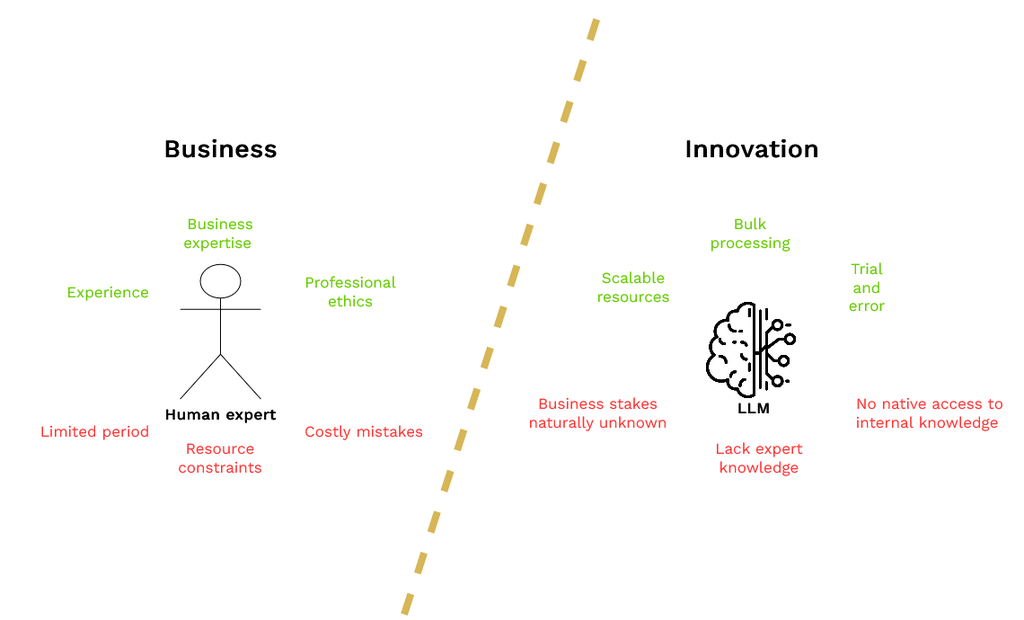

## 8.7 Human ground truth, machine scaling

Human and Virtual Annotation

### NACE 2.1 ground truth campaign

- ~30k annotations directly in NACE 2.1
- ~25 NACE experts
- Focused on one-to-many cases (the hard ones)

### What we learned

**Expert agreement is imperfect**

- 3-experts blind re-annotation: 62 % strict agreement, 96 % majority
- Experts are far from converging systematically: we stay cautious when interpreting our precision metrics

**Explicit reasoning protocol**

- Description, then check the legacy code, then consult candidates and explanatory notes, then decide
- A sequence we can encode into an LLM prompt at scale

## 8.8 3. Methodology

## 8.9 Rule-Based Augmented Generation as constrained selection

Methodology

**Why not ask the LLM directly?**

- **732 codes** is too large a space for reliable open generation.
- Hallucinations are very frequent.
- Capabilities depend heavily on the LLM’s implicit knowledge base.

**Constrained selection instead:**

- For each observation, we already know the **NACE 2.0 code**
- The correspondence table gives the **set of admissible NACE 2.1 codes**
- The task becomes: **pick the right code from a short, restricted list**
- Output aligned with official rules

## 8.10 The pipeline

Methodology

**For each observation**:

1. Retrieve the activity description (free text + optional precisions: secondary activity, legal category)
2. Retrieve the legacy NACE 2.0 code
3. Use the correspondence table to get the set of candidate NACE 2.1 codes
4. Inject the **explanatory notes** of each candidate code into the prompt
5. Ask the LLM to pick the most appropriate code
6. Parse the structured JSON response

A form of **Rule-Based Augmented Generation (RBAG)** with a deterministic retriever.

**Inputs to the prompt**

| Element | Source |
| --- | --- |
| Activity text + precisions | Production register |
| NACE 2.0 code | Insee NACE Experts |
| Candidate set | Correspondence table |
| Explanatory notes | Official NACE 2.1 documentation |

## 8.11 The prompt structure

Methodology

**System prompt** — same for every observation

> *You are an expert in the NACE classification. Your task is to assign a NACE 2.1 code to a business based on its activity description, using a candidate list derived from the existing NACE 2.0 code…*

**User prompt** — observation-specific

```
# Main activity : {{activity}}
# NACE 2.0 code : {{nace_old}}
# Candidate NACE 2.1 codes + notes : {{proposed_codes}}
========
# Instructions (7 rules)
  → candidate list only — no external code
  → first activity only
  → strict JSON — no explanation
```

**Expected output**

```json
{
  "codable": true,
  "nace2.1": "0147J",
  "nace_legacy_valid": true,
  "confidence": 0.92
}
```

- `nace2.1`: the chosen code (or `null`)
- `codable`: was the description sufficient?
- `confidence`: model self-assessment (0–1)
- `nace_legacy_valid`: is the legacy code consistent?

**`{proposed_codes}`** — example:

```
86.95: Physiotherapy activities
  Includes: physiotherapy, medical massage, occupational therapy, praxitherapy…
  Does not include: osteopaths, chiropractors, non-medical massage parlors…

86.96: Traditional, complementary, and alternative medicine  [...]
86.99: Other human health activities n.e.c.  [...]
```

## 8.12 Multi-model annotation

Methodology

| Model | Size | Inference speed | Behaviour |
| --- | --- | --- | --- |
| Qwen3-6-35B MoE | 35B | Very fast (13 it/s) | Moderately restrictive |
| Qwen3-6-35B MoE + thinking | 35B | Less fast (1 it/s) | Less restrictive |
| Gemma4-26B MoE | 26B | Fast (8 it/s) | Moderately restrictive |

➕️ **Aggregation**: majority vote.

Different sizes, different throughput.

## 8.13 4. Infrastructure

## 8.14 Our MLOps stack on the SSPCloud

Infrastructure

**SSPCloud** is Insee’s data science platform, built on the open-source **Onyxia** project and powered by **Kubernetes** as its underlying technology stack.

Main elements of the technical stack:

- **MinIO** — S3-compatible storage for datasets and model artifacts
- **llm.lab** — SSPCloud’s LLM provider on premise, (**OpenWebUI + vLLM**)
- **Langfuse** — prompt versioning
- **MLflow** — experiment tracking
- **Argo Workflows** — the end-to-end pipeline orchestrator

Entirely open-source, containerised, reproducible.

## 8.15 5. Results

## 8.16 Grading the LLM annotators

Results

- Reference: the **~30,000 manually annotated** one-to-many cases (NACE 2.1, level 5)
- Three complementary accuracies — at the most detailed level (sub-class):
  1. **Overall** — across all observations
  2. **Codable subset** — restricted to predictions the LLM itself flagged as codable
  3. **LLM-only**: restricted to cases where the true code is in the candidate list (isolates the LLM’s choice quality)

## 8.17 Per-model and ensemble accuracy

Results

Accuracies at level 5 (sub-class) — % of cases where the predicted code matches the manual annotation.

| Model | Inference | Overall | Codable | LLM-only |
| --- | --- | --- | --- | --- |
| Qwen3-6-35B MoE | 13 it/s | 75.2 % | 78.3 % | 83.3 % |
| Qwen3-6-35B MoE + thinking | ~1 it/s | 75.7 % | 80.4 % | 84.1 % |
| Gemma4-26B MoE | 8 it/s | 75.2 % | 80.0 % | 83.5 % |
| **Majority vote** | — | **78.3 %** | — | **86.9 %** |

The codable filter is per-model, hence the dash for the ensemble vote.

Ensemble accuracy comes at a real cost: three full inference passes, one of them in thinking mode (~10× slower).

A substantial share of disagreements are not LLM errors but ambiguous descriptions or legacy-coding mistakes.

## 8.18 Rebuilding the training set

Results

Once happy with the LLM on the benchmark, we apply at scale:

**Tip**

This is **semi-synthetic** training set: real businesses, real descriptions, but algorithmic labels.

## 8.19 Performance of the retrained classifier

Results

**TorchTextClassifiers** retrained on the semi-synthetic corpus

~80 %

overall accuracy on a representative NACE 2.1 test set

**≈** the legacy NACE 2.0 classifier on its NACE 2.0 task

*Last retrain used an earlier vintage of the corpus; today’s pipeline produces better labels.*

**Semi-synthetic LLM-generated labels can substitute for manual annotations in the early stages of a classification transition.**

## 8.20 Recap

[figure not shown]

## 8.21 6. Conclusion and Perspectives

## 8.22 Take-aways and what’s next

Conclusion and Perspectives

**Take-aways**

- A practical method to handle classification revisions in production ML
- LLMs as **virtual annotators** scale where humans cannot
- Semi-synthetic labels reach **production-grade accuracy** (~80 %)
- Fully open-source, reproducible MLOps stack

**Limits & ongoing work**

- Inference cost is non-trivial at ~1 M queries
- Legacy errors are inherited
- Explore RAG variants

# 9 Questions ?

- Nathan RANDRIAMANANA
- Data Scientist
- Sirene
- Insee — France
- nathan.randriamanana@insee.fr